| Hazırlayan | Versiyon | Tarih | Dil |
| --- | --- | --- | --- |
| dataFLOYD | v1.00 | 17 Ekim 2018 | TR |

# Derin Öğrenme (Deep Learning) - Keras ile Basit bir Sınıflandırıcı Yapımı

Uzun bir seri olacağını düşündüğüm derin öğrenme (deep learning:DL) konusuna bu yazı ile uygulamalı bir giriş yapmak istiyorum.Bildiğiniz gibi derin öğrenme konusuna son birkaç yıldır oldukça büyük bir ilgi var. Bu ilgi boşuna değil tabii ki; derin öğrenme "computer vision" (bilgisayarlı görü), "natural language processing" (doğal dil işleme), "speech recognition" (konuşma tanıma) gibi birçok alanda oldukça başarılı sonuçlar ortaya çıkarıyor. Klasik makine öğrenmesinin ve algoritmaların yetersiz kaldığı durumlarda insan performansına yakın sonuçların elde edilmesini sağlayabiliyor.

Hiç kimse endişelenmesin basit bir örnekle başlayacağız, bu örnekte "tensorflow" ve "keras" kütüphanesini kullanarak "MNIST Fashion" veritabanında basit bir model oluşturacağız. Örneği hazırlarken "tensorflow" sayfasındaki öğreticileri baz aldım. Eğer anlamadığınız bir nokta olursa bu öğreticilere de göz atabilirsiniz veya benimle iletişime geçebilirsiniz.

## Tensorflow ve Keras

Tensorflow ve Keras'ı bilenler zaten biliyordur, ben buradan bu ikiliyi daha önce duymayan azınlığa seslenmek istiyorum: Eğer derin öğrenme konusunda çalışmak istiyorsanız bu iki paket hayatınızın vazgeçilmez bir parçası olacak, sizlere garanti veririm.

### Kısaca Tensorflow

"Tensorflow"un ilk versiyonu "Google Brain Team" tarafından Kasım 2015'te yayınlandı. Resmi tanımlaması ise şu şekilde: *"TensorFlow is an open-source software library for dataflow programming across a range of tasks. It is a symbolic math library, and is also used for machine learning applications such as neural networks.It is used for both research and production at Google"*.  
"Dataflow programming", "symbolic math" gibi kavramları bir kenara koyarsak tensorflow halk arasındaki tabiri ile Google'ın yaptığı derin öğrenme aracıdır diyebiliriz :)

Internet sayfası:  
https://www.tensorflow.org/

### Kısaca Keras

*François Chollet* tarafından geliştirilen Keras Yunanca'da boynuz demekmiş. Yunan mitolojisine dayanan bu ismin orjini konusunda kafanızı şişirmeyeceğim merak etmeyin. Bu yazıyı okuyorsanız zaten hepiniz akıllı insanlarsınız demektir, isteyen kolaylıkla Keras ne demekmiş nereden geliyormuş, araştırıp bulabilir :)

Keras paketi resmi sitesinde şu şekilde tanımlanıyor: *"Keras is a high-level neural networks API, written in Python and capable of running on top of TensorFlow, CNTK, or Theano. It was developed with a focus on enabling fast experimentation. Being able to go from idea to result with the least possible delay is key to doing good research."*  
Birebir tercümesi değil ama Keras'ı kullanırsanız tensorflow deneyiminiz daha kolay olur demek isteniyor...

Internet sayfası  
https://keras.io/

## Veri önemlidir: MNIST ve MNIST Fashion veri seti

Kullanacağımız veri ile ilgili biraz ön bilgi vereyim. Bu çalışmada MNIST Fashion verisetini kullanacağız.

"MNIST fashion" meşhur MNIST (Modified National Institute of Standards and Technology database) veri setinin yerini almayı hedef edinen, MNIST'e göre daha kompleks resimler içeren bir veri seti.

MNIST veritabanı; Yann LeCun, Corinna Cortes, Christopher J.C. Burges tarafından 1998 yılında hazırlanmış, 0'dan 9'a kadar olan rakamların el yazısı örneklerini içeren bir veri setidir. Kolay erişilebilir ve küçük boyutlu olması nedeniyle, makine öğrenmesi problemleri için "Hello World!" örneklerinde kullanılır.

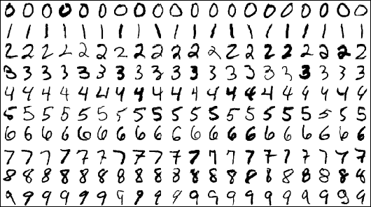

*MNIST veri seti örnekleri*

Yan LeCun 1998'de yayımlanan meşhur CNN makalesinde bu verisetini kullanmıştır. Makaleye bakmanızı tavsiye ederim, eğer sizlerden yeterli talep gelirse birgün bu makalenin üzerinden geçtiğimiz bir yazı hazırlamayı düşünebilirim :)

[Gradient Based Learning Applied to Document Recognition](http://yann.lecun.com/exdb/publis/pdf/lecun-01a.pdf)

## Başlamadan önce ufak bir öneri: Google Colab kullanın!

Eğer burada bahsedilen kodları çalıştırmak istiyorsanız ve geliştirme ortamı kurulmuş bir bilgisayarınız yoksa **Google Colab** kullanmanızı tavsiye ederim. Google Colab; hiçbir kurulum gerektirmeyen doğrudan tarayıcınız üzerinden çalıştırabileceğiniz bir "Jupyter Notebook" ortamı. **En güzel kısmı ise bu ortam sayesinde Google serverlarındaki TPU (tensor processing unit) ve GPU'ları bedava olarak kullanabilirsiniz :)**

Aşağıdaki adresten Google Colab'e erişmeniz mümkün. Bu dosyayı tamamen veya dosyanın içindeki kod parçalarını orada çalıştırmanız mümkün. Önümüzdeki günlerde "Google Colab" ile ilgili ayrı bir yazı hazırlayacağım bilgisini de sizinle paylaşmak istiyorum.

https://colab.research.google.com

## Başlayalım o halde...

Evet hazırsak MNIST Fashion veri seti için basit bir mimariye sahip sınıflandırıcımızı oluşturmaya başlayalım. Öncelikle gerekli kütüphaneleri "import" edelim.

```python
# tensorflow ve keras gelin bakalım buraya
import tensorflow as tf
import keras

# numpy ve matplotlib kütüphaneleri her eve lazımdır!
import numpy as np
import matplotlib.pyplot as plt
```

Notebook biraz daha güzel görünsün ve standart olsun dediğimiz için aşağıdaki eklemeleri de yapıyoruz.

```python
%matplotlib notebook
# Seaborn dark theme tercihimizdir :)
import seaborn as sns
sns.set_style("darkgrid")
```

Not: *numpy* ve *matplotlib* ile ilgili daha önceden hazırladığım yazıların bağlantılarını da vereyim ihtiyacınız olursa bakarsınız:  
**[Python “matplotlib” kütüphanesini kullanarak veri görselleştirme – Temel Grafikler](https://www.datafloyd.com/tr/pyhton-matplotlib-kutuphanesini-kullanarak-veri-gorsellestirme-temel-grafikler%c2%b6/)**</li>  
**[Python “pandas” kütüphanesine giriş](https://www.datafloyd.com/tr/python-pandas-kutuphanesine-giris/)**

```python
# Veri setini yükleyelim
fashion_mnist = keras.datasets.fashion_mnist
```

Şimdi yukarıdaki satırda bir nesne hazırlamış olduk, içindeki veriyi alabilmek için *load_data* metodunu kullanmamız gerekiyor. Eğer daha önceden veriyi indirmediyseniz bu metot bir indirme işlemi başlatacak.

```python
# Bu fonksiyon veriyi test ve train olmak üzere iki set halinde veriyor
(train_images, train_labels), (test_images, test_labels) = fashion_mnist.load_data()
```

Öncelikle verinin boyutlarına bakalım

```python
print("Eğitim setinin boyutu: ")
print(train_images.shape)
print("Test setinin boyutu: ")
print(test_images.shape)
```

```
Eğitim setinin boyutu:
(60000, 28, 28)
Test setinin boyutu:
(10000, 28, 28)
```

Gördüğümüz gibi 60000 adet örnek eğitim setinde, 10000 adet örnek test setinde mevcut. Her bir imgenin boyutunun da 28x28 olduğunu görüyoruz. Sadece iki boyut olması imgelerimizin siyah-beyaz olduğu anlamına geliyor.

```python
# Eğitim ve test setindeki eşsiz sınıf sayısı
unique_classes,u_counts = np.unique(np.concatenate([train_labels,test_labels]),return_counts=True)
print(unique_classes)
print(u_counts)
```

```
[0 1 2 3 4 5 6 7 8 9]
[7000 7000 7000 7000 7000 7000 7000 7000 7000 7000]
```

Toplamda 10 adet sınıf var, ne yazık ki bu sınıfların hangi giysilere ait olduğu veri setinin içinde yazmıyor. Bunun için sınıfların yazdığı bir liste oluşturalım.

```python
class_names = ['Tişört / Üst', 'Pantolon', 'Kazak', 'Elbise', 'Ceket',
               'Sandal', 'Gömlek', 'Spor Ayakkabı', 'Çanta', 'Çizme']
```

Her sınıftan birkaç örnek görelim isterseniz.

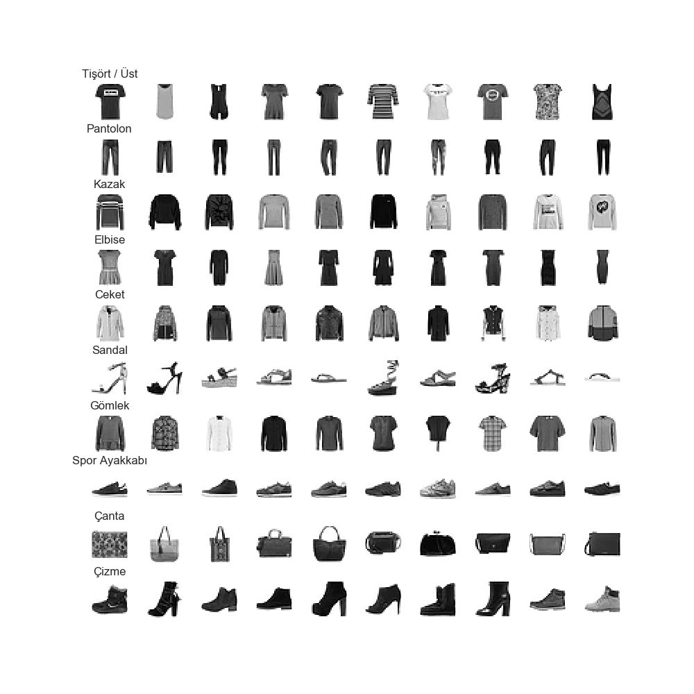

```python
num_of_samples_per_class = 10
num_classes = len(unique_classes)


fig, axes = plt.subplots(nrows=num_classes,
                         ncols=num_of_samples_per_class,
                         figsize=(num_classes,num_of_samples_per_class))

# Tüm sınıflar üzerinden dolaşalım
for ix,current_class in enumerate(unique_classes):

    # Örnek sayısı kadar dolaşalım
    for iy,current_sample in enumerate(range(num_of_samples_per_class)):

        # sıradaki örneğin indeksini bulalım
        index = np.where([train_labels == current_class])[1][current_sample]

        # imgeyi hazirlayalim
        current_image = train_images[index]

        # num_classes x num_of_samples kadar bir subplot yapalım
        axes[ix][iy].imshow(current_image, cmap=plt.cm.binary)
        axes[ix][iy].set_xticks([])
        axes[ix][iy].set_yticks([])


# Adding class names
for ax, row in zip(axes[:,0], class_names):
    ax.set_title(row, rotation=0, size='large')

plt.subplots_adjust(hspace=0.5,wspace=0.2)
```

Çok güzel hazırlanmış bir veri seti değil mi?Toplamda 10 sınıf ve her sınıftan 7000 adet örnek var. Kolay bir iş değil yapanlara selam ve saygılarımı gönderiyorum.

## Sınıflandırma yapabilmek için mimarinin hazırlanması

Her yapay sinir ağı çeşitli katmanlardan oluşur. Bu katmanlar temel olarak "girdi katmanı", "gizli katman(lar)" ve "çıktı katmanı" olarak gruplandırılabilir. Yukarıdaki veri setinde bulunan 10 sınıfı birbirinden ayırt edebilmek için işe basit bir mimari kurarak başlayalım.

*Not:Temel yapay sinir ağları bilgilerinizi tazelemek aşağıdaki yazılara bakmanızı tavsiye ederim:*  
**[Yapay Sinir Ağları 1.Bölüm](https://www.datafloyd.com/tr/yapay-sinir-aglari-neural-networks-1-bolum-tek-bir-noron-hakkinda/)**  
**[Yapay Sinir Ağları 2.Bölüm](https://www.datafloyd.com/tr/yapay-sinir-aglari-neural-networks-2-bolum/)**

```python
model = keras.Sequential([
    keras.layers.Flatten(input_shape=(28, 28)),
    keras.layers.Dense(128, activation=tf.nn.relu),
    keras.layers.Dense(10, activation=tf.nn.softmax)
])
```

```python
model.compile(optimizer=tf.train.AdamOptimizer(),
              loss='sparse_categorical_crossentropy',
              metrics=['accuracy'])
```

Burada da temel olarak 3 parametre görmekteyiz. Bunlar

- `optimizer` Ağımızın parametrelerinin güncellenmesi için kullanılır. Bunu "loss" fonksiyonuna ve veriye bakarak yapar.
- `loss` Optimizasyon sırasında modelin ne kadar doğru olduğunu ölçmede kullanılır.Eğitim sırasında bu metriği minimize etmeye çalışırız.
- `metrics` Eğitim ve test adımlarında tüm veri seti üzerinden çıkarılan bir metriktir. "Accuracy" örneklerin ne kadar doğru sınıflandırıldığını ölçer.

Modeli hazırlayıp derlediğimize göre şimdi geriye bu modeli eğitmek kaldı. Bu da *Keras* sayesinde oldukça basit bir işlem. Hızlı bir sonuç alabilmek için toplam 5 "epoch" seçelim. 1 "epoch" tüm eğitim setinin ileri ve geri yönde modelden 1 kere geçirilmesi olarak tanımlanmaktadır.

## Normalizasyonun önemi

Sınıflandırmaya geçmeden önce çok önemli olan normalizasyon konusunu hatırlatmak istiyorum. Genel olarak hemen hemen tüm makine öğrenmesi problemlerinde girdi sağladığınız vektörleri normalize etmeniz gerekir. Bunu yapmanın çeşitli yöntemleri vardır.

İmgeler için genel olarak tercih edilen yöntem imgeyi alabileceği maksimum değere yani siyah-beyaz imgeler için 255'e bölerek normalize etmektir.

Aman dikkat edelim eğitim ve test setinin normalizasyonunu aynı şekilde yapmamız gerekiyor yoksa bu "accuracy" neden artmıyor diye bakınıp dururuz :)

Normalizasyonun önemini daha iyi anlatabilmek adına ilk önce imgeleri normalize etmeden modelimizi eğitelim

```python
model.fit(train_images, train_labels, epochs=5)
```

```
<keras.callbacks.History at 0x2260ea3bda0>
```

```python
train_images = train_images / 255.0
test_images = test_images / 255.0
model.fit(train_images, train_labels, epochs=5)
```

```
<keras.callbacks.History at 0x2260ed23b70>
```

## Modelin değerlendirilmesi

Keras'ın yazarı *François Chollet* Bey bizim için herşeyi düşünmüş, Keras ile hazırlanan modeli değerlendirmek o kadar kolay ki tek satır kod ile bunu gerçekleştirebilirsiniz. İnanmadıysanız yazıyorum:

```python
test_loss, test_acc = model.evaluate(test_images, test_labels)
```

Değerlendirme bitti bu kadar :) Yukarıda tek satır sözü verdiğim için "print" kısmını yazmayarak bir mini çakallık gerçekleştirmiş olabilirim, onu da aşağıda yazıyorum.

```python
print("Test seti \"accuracy\" değeri {:.2f}".format(test_acc))
```

```
Test seti "accuracy" değeri 0.88
```

Vay be test bu kadar basit bir model ile bile göreceli olarak yüksek bir değer yakaladık. Bir sonraki adımda isterseniz tahminleri biraz daha yakından inceleyelim

## Tahminlerin incelenmesi

Öncelikle tüm test seti üzerinde tahminleme işlemini gerçekleştirelim.

```python
predictions = model.predict(test_images)
predictions.shape
```

```
(10000, 10)
```

Tahminler gördüğünüz gibi $10000\times10$ luk bir vektör olarak karşımıza çıktı. Yani tahmin edilen örnek sayısı çarpı sınıf sayısı kadar bir matrisimiz var. Bu matrisin her bir satırı o satırdaki örneğin hangi sınıfa ne kadar benzediğini ifade eden bir vektör. Bu vektör "softmax" çıktısı olduğu için toplamının bir olması gerekiyor. İsterseniz ilk satırda deneyerek öncelikle bunu doğrulayalım

```python
sum(predictions[0])
```

```
1.0000000157998183
```

Tam bir değil ama neredeyse 1, o kadar kusur kadı kızında da olur diyelim. Ama bir de tüm elemanları toplamadan da geçmeyelim bu kısmı. Bunun da teoride 10000 etmesi gerekiyor.

```python
sum(sum(predictions))
```

```
9999.944458007812
```

10000'e çok yakın ama tam 10000 değil ne yazık ki.. Canınızı sıkmak istemem ama "dijital dünyada" bu tip "precision" hataları kaçınılmaz malesef.

"Precision" hatalarını her gördüğümde *Matrix: Reloaded* filmindeki "Architect" ile "Neo" nun karşılaşması aklıma gelir orada "Architect" şunları söylemektedir.

*"Your life is the sum of a remainder of an unbalanced equation inherent to the programming of the Matrix. You are the eventuality of an anomaly, which despite my sincerest efforts I have been unable to eliminate from what is otherwise a harmony of mathematical precision."*

Düşünün artık "Architect" bile Matrix'i yaparken bu tip hatalardan kaçamamış ama bunun sonucunda Neo ortaya çıkmış!

[figure not shown]

"Machine Precision" hatalarının kaçınılmaz olduğunu bir kenara not edelim ve bu tahminleri biraz görselleştirerek yolumuza devam edelim.

```python
# Tahminleri görselleştirmek için bir fonksiyon yazalım
def plot_predictions_and_image(sample_num):
    plt.figure(figsize=(7,3))
    plt.subplot(1,2,2)
    # Bar grafik güzel görünür
    bars = plt.barh(class_names,predictions[sample_num], color="#777777")

    # Tahmin edilen sınıfı, gerçek sınıfı ve güvenirliği bulalım
    pred_class = class_names[np.argmax(predictions[sample_num])]
    real_class = class_names[test_labels[sample_num]]
    confidence = np.max(predictions[sample_num])

    # Eğer doğru sınıflandırma gerçekleşirse mavi
    # gerçekleşmezse kırmızı sütun çizelim
    if pred_class==real_class:
        bars[np.argmax(predictions[sample_num])].set_color("b")
    else:
        bars[np.argmax(predictions[sample_num])].set_color("r")


    plt.subplot(1,2,1)
    # imgeyi gösterelim
    plt.imshow(test_images[sample_num],cmap=plt.cm.binary)
    plt.xticks([])
    plt.yticks([])
    plt.title("Gerçekte: {:}".format(real_class)
              + "\n" +
             "Tahmin edilen: {:} ({:.2f})".format(pred_class,confidence) )
    plt.subplots_adjust(wspace=0.5)
```

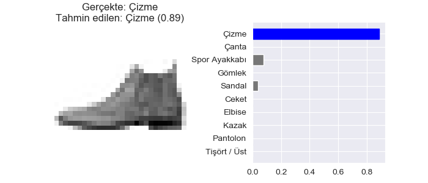

[figure not shown]

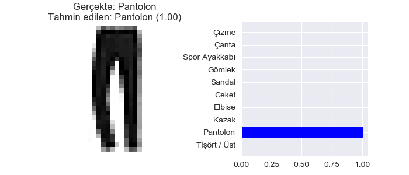

```python
plot_predictions_and_image(0)
plot_predictions_and_image(1)
plot_predictions_and_image(2)
```

Birkaç tane de yanlış sınıflandırılan örneğe bakalım.

```python
pred_labels = np.argmax(predictions,axis=1)
misclassified= np.where(test_labels != pred_labels)[0]
print("Yanlış sınıflandırılan örnek sayısı: {:} / {:}".format(len(misclassified),len(pred_labels)) )
```

```
Yanlış sınıflandırılan örnek sayısı: 1237 / 10000
```

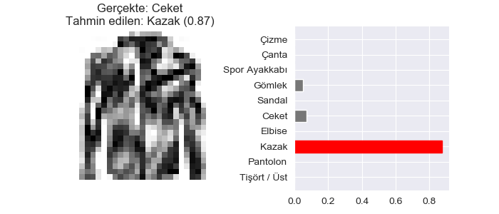

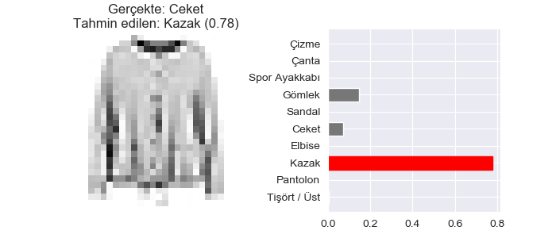

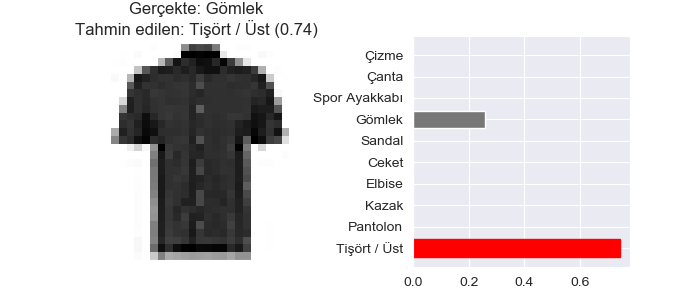

```python
plot_predictions_and_image(misclassified[0])
plot_predictions_and_image(misclassified[1])
plot_predictions_and_image(misclassified[2])
```

Buraya kadar okuduğunuz için çok teşekkürler! Bir başka yazımızda görüşmek üzere